# XGR: eXploring Genomic Relations at gene and SNP level through enrichment analysis, similarity analysis and network analysis

### 4.1.4 Gene-based network analysis

> Identify a gene subnetwork from an input list of (significant) eGenes

```r
# find maximum-scoring gene subnetwork with the desired node number=50
data <- cis_df[,c("eGene","FDR_stimulus")]
subnet <- xSubneterGenes(data=data, network="STRING_high", subnet.size=50, RData.location=RData.location)
```

The identified gene subnetwork with nodes colored according to FDR is shown below:

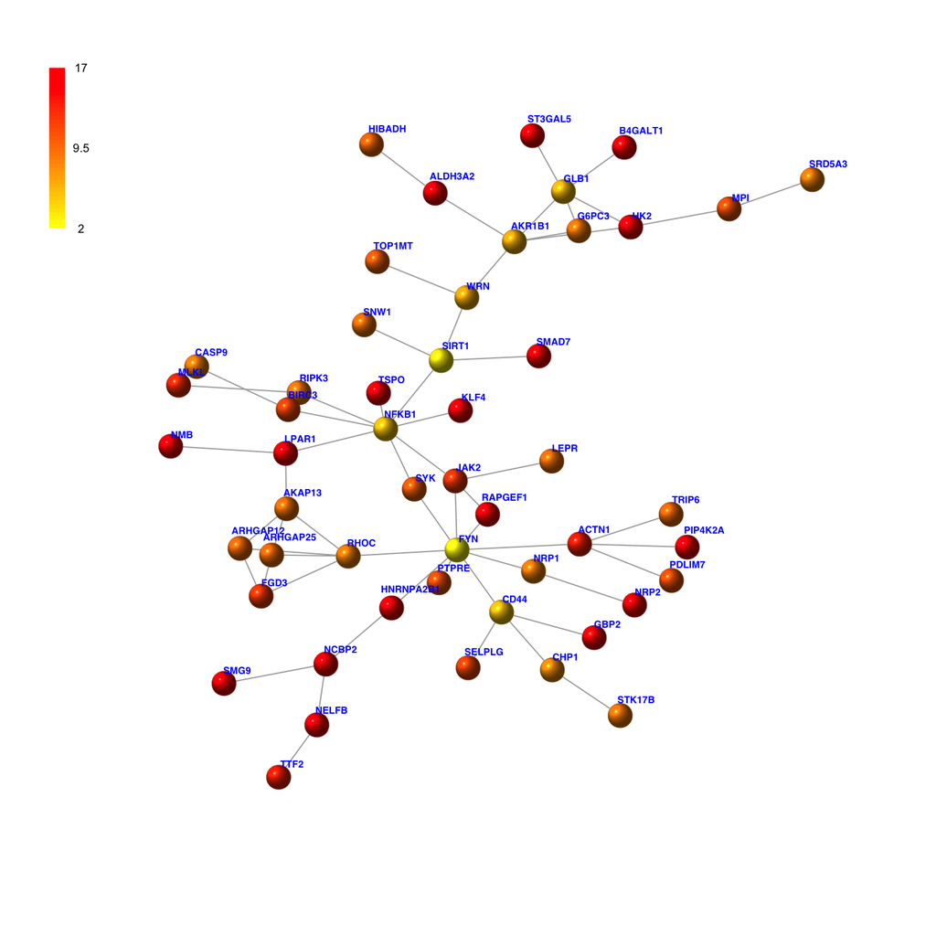

```r
pattern <- -log10(as.numeric(V(subnet)$significance))
pattern[is.infinite(pattern)] <- max(pattern[!is.infinite(pattern)])
vmax <- ceiling(stats::quantile(pattern, 0.75))
vmin <- floor(min(pattern))
xVisNet(g=subnet, pattern=pattern, glayout=layout_(subnet, with_kk()), vertex.shape="sphere", colormap="yr", zlim=c(vmin,vmax), newpage=F, edge.arrow.size=0.3, vertex.label.color="blue", vertex.label.dist=0.35, vertex.label.font=2)
```

> Identify pathways enriched with genes in the identified subnetwork

```r
data <- V(subnet)$name
eTerm <- xEnricherGenes(data=data, ontology="MsigdbC2CP", RData.location=RData.location)
# view enrichment results for the top significant terms
xEnrichViewer(eTerm)
# save enrichment results to the file 'Subnet_Pathway_enrichments.txt'
res_subnet_PW <- xEnrichViewer(eTerm, top_num=length(eTerm$adjp), sortBy="adjp", details=F)
output <- data.frame(term=rownames(res_subnet_PW), res_subnet_PW)
write.table(output, file="Subnet_Pathway_enrichments.txt", sep="\t", row.names=F)
```

Enrichment results for the top 10 significant pathways are shown below:

| name | nAnno | nOverlap | zscore | pvalue | adjp |
| --- | --- | --- | --- | --- | --- |
| Osteopontin-mediated events | 31 | 3 | 5.89 | 6.0e-05 | 0.00042 |
| EPO signaling pathway | 34 | 3 | 5.59 | 8.7e-05 | 0.00042 |
| HIV-1 Nef: Negative effector of Fas and TNF-alpha | 35 | 3 | 5.49 | 9.8e-05 | 0.00042 |
| IFN-gamma pathway | 40 | 3 | 5.07 | 1.7e-04 | 0.00048 |
| amb2 Integrin signaling | 41 | 3 | 5.00 | 1.8e-04 | 0.00048 |
| Signaling events mediated by PTP1B | 52 | 3 | 4.31 | 4.6e-04 | 0.00100 |
| Signaling events mediated by focal adhesion kinase | 59 | 3 | 3.97 | 7.5e-04 | 0.00140 |
| Fc-epsilon receptor I signaling in mast cells | 62 | 3 | 3.85 | 9.1e-04 | 0.00150 |
| Signaling events mediated by HDAC Class I | 66 | 3 | 3.69 | 1.2e-03 | 0.00150 |
| LPA receptor mediated events | 66 | 3 | 3.69 | 1.2e-03 | 0.00150 |

### 4.1.5 SNP-based network analysis

> Identify a gene subnetwork from an input list of (significant) eQTLs

```r
# find maximum-scoring gene subnetwork with the desired node number=50
data <- cis_df[,c("eQTL","FDR_stimulus")]
subnet_SNP <- xSubneterSNPs(data=data, network="STRING_high", distance.max=200000, seed.genes=T, subnet.significance=1e-1, subnet.size=50, RData.location=RData.location)
```

The identified gene subnetwork with nodes colored according to scores is shown below:

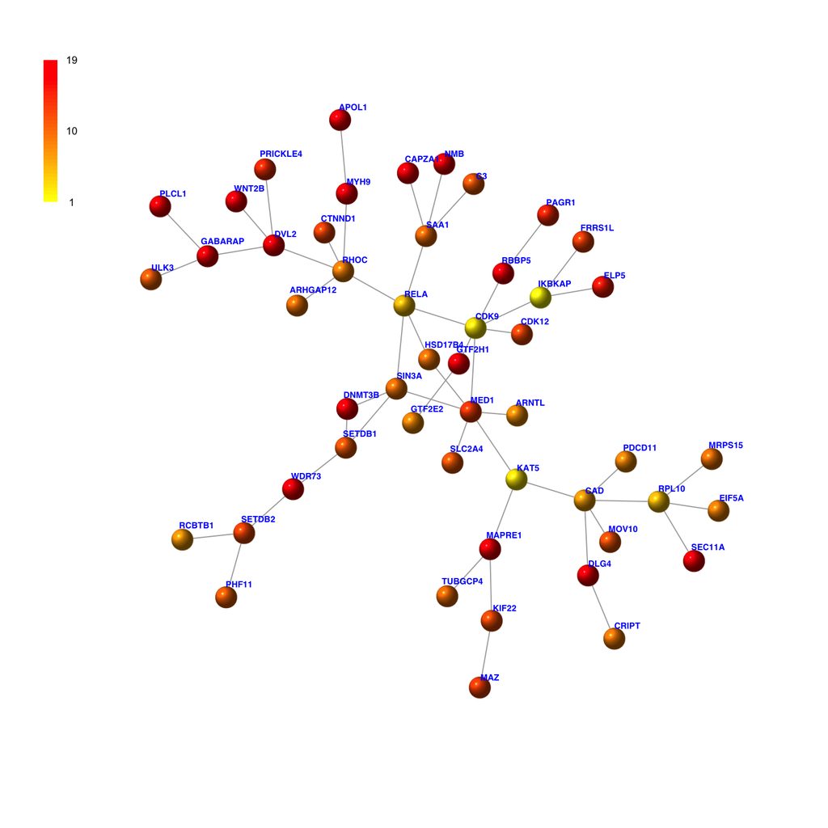

```r
pattern <- -log10(as.numeric(V(subnet_SNP)$significance))
pattern[is.infinite(pattern)] <- max(pattern[!is.infinite(pattern)])
vmax <- ceiling(stats::quantile(pattern, 0.75))
vmin <- floor(min(pattern))
xVisNet(g=subnet_SNP, pattern=pattern, glayout=layout_(subnet_SNP, with_kk()), vertex.shape="sphere", colormap="yr", zlim=c(vmin,vmax), newpage=F, edge.arrow.size=0.3, vertex.label.color="blue", vertex.label.dist=0.35, vertex.label.font=2)
```

> Identify enriched pathways for the identified subnetwork

```r
data <- V(subnet_SNP)$name
eTerm <- xEnricherGenes(data=data, ontology="MsigdbC2CPall", RData.location=RData.location)
# view enrichment results for the top significant terms
xEnrichViewer(eTerm)
# save enrichment results to the file 'Subnet_SNP_Pathway_enrichments.txt'
res_subnet_SNP_PW <- xEnrichViewer(eTerm, top_num=length(eTerm$adjp), sortBy="adjp", details=F)
output <- data.frame(term=rownames(res_subnet_SNP_PW), res_subnet_SNP_PW)
write.table(output, file="Subnet_SNP_Pathway_enrichments.txt", sep="\t", row.names=F)
```

Enrichment results for the top 10 significant pathways are shown below:

| name | nAnno | nOverlap | zscore | pvalue | adjp |
| --- | --- | --- | --- | --- | --- |
| Mechanism of Gene Regulation by Peroxisome Proliferators via PPARa(alpha) | 58 | 3 | 5.78 | 7.7e-05 | 0.0010 |
| RNA Polymerase II Pre-transcription Events | 60 | 3 | 5.67 | 8.8e-05 | 0.0010 |
| Transcriptional Regulation of White Adipocyte Differentiation | 72 | 3 | 5.09 | 1.8e-04 | 0.0014 |
| Late Phase of HIV Life Cycle | 103 | 3 | 4.07 | 7.1e-04 | 0.0034 |
| RNA Polymerase II Transcription | 104 | 3 | 4.04 | 7.4e-04 | 0.0034 |
| HIV Life Cycle | 121 | 3 | 3.65 | 1.3e-03 | 0.0050 |
| Factors involved in megakaryocyte development and platelet production | 130 | 3 | 3.48 | 1.7e-03 | 0.0056 |
| Fatty acid, triacylglycerol, and ketone body metabolism | 168 | 3 | 2.88 | 4.3e-03 | 0.0098 |
| Innate Immune System | 272 | 4 | 2.85 | 4.2e-03 | 0.0098 |
| Developmental Biology | 388 | 5 | 2.84 | 3.9e-03 | 0.0098 |

# 5 Session Info

Here is the output of `sessionInfo()` on the system on which this vignette was compiled:

```
> R version 3.2.4 (2016-03-10)
> Platform: x86_64-apple-darwin13.4.0 (64-bit)
> Running under: OS X 10.11.4 (El Capitan)
>
> locale:
> [1] en_GB.UTF-8/en_GB.UTF-8/en_GB.UTF-8/C/en_GB.UTF-8/en_GB.UTF-8
>
> attached base packages:
> [1] stats     graphics  grDevices utils     datasets  methods   base
>
> other attached packages:
> [1] RCircos_1.1.3  stringr_1.0.0  XGR_1.0.0      dnet_1.0.7
> [5] supraHex_1.7.3 hexbin_1.27.1  igraph_1.0.1
>
> loaded via a namespace (and not attached):
>  [1] Biobase_2.28.0            foreach_1.4.3
>  [3] splines_3.2.4             Formula_1.2-1
>  [5] highr_0.5.1               stats4_3.2.4
>  [7] latticeExtra_0.6-28       RBGL_1.44.0
>  [9] BSgenome_1.36.3           Rsamtools_1.20.4
> [11] yaml_2.1.13               RSQLite_1.0.0
> [13] lattice_0.20-33           biovizBase_1.16.0
> [15] digest_0.6.9              GenomicRanges_1.20.8
> [17] RColorBrewer_1.1-2        XVector_0.8.0
> [19] colorspace_1.2-6          ggbio_1.16.1
> [21] htmltools_0.3             Matrix_1.2-4
> [23] plyr_1.8.3                OrganismDbi_1.10.0
> [25] XML_3.98-1.3              biomaRt_2.24.0
> [27] zlibbioc_1.14.0           scales_0.4.0
> [29] BiocParallel_1.2.18       IRanges_2.2.9
> [31] ggplot2_2.1.0             GenomicFeatures_1.20.1
> [33] nnet_7.3-12               BiocGenerics_0.14.0
> [35] survival_2.38-3           magrittr_1.5
> [37] evaluate_0.8.3            GGally_1.0.1
> [39] nlme_3.1-125              MASS_7.3-45
> [41] foreign_0.8-66            graph_1.46.0
> [43] tools_3.2.4               doMC_1.3.4
> [45] formatR_1.3               S4Vectors_0.6.6
> [47] munsell_0.4.3             cluster_2.0.3
> [49] AnnotationDbi_1.30.1      lambda.r_1.1.7
> [51] Biostrings_2.36.1         compiler_3.2.4
> [53] GenomeInfoDb_1.4.3        futile.logger_1.4.1
> [55] grid_3.2.4                RCurl_1.95-4.7
> [57] iterators_1.0.8           dichromat_2.0-0
> [59] VariantAnnotation_1.14.13 bitops_1.0-6
> [61] rmarkdown_0.9.5           codetools_0.2-14
> [63] gtable_0.2.0              DBI_0.3.1
> [65] reshape_0.8.5             reshape2_1.4.1
> [67] GenomicAlignments_1.4.1   gridExtra_2.2.1
> [69] knitr_1.12.3              rtracklayer_1.28.6
> [71] Hmisc_3.17-2              futile.options_1.0.0
> [73] Rgraphviz_2.12.0          ape_3.4
> [75] stringi_1.0-1             parallel_3.2.4
> [77] Rcpp_0.12.4               rpart_4.1-10
> [79] acepack_1.3-3.3
```

Ashburner, M, C A Ball, J A Blake, D Botstein, H Butler, J M Cherry, A P Davis, et al. 2000. “Gene ontology: tool for the unification of biology. The Gene Ontology Consortium.” *Nat Genet* 25 (1): 25–29. doi:10.1038/75556.

Fairfax, Benjamin P, Peter Humburg, Seiko Makino, Vivek Naranbhai, Daniel Wong, Evelyn Lau, Luke Jostins, et al. 2014. “Innate immune activity conditions the effect of regulatory variants upon monocyte gene expression.” *Science (New York, N.Y.)* 343 (March): 1246949. doi:10.1126/science.1246949.

Fang, Hai, and Julian Gough. 2014. “The ’dnet’ approach promotes emerging research on cancer patient survival.” *Genome Medicine* 6 (8): 64. doi:10.1186/s13073-014-0064-8.

Köhler, Sebastian, Sandra C Doelken, Christopher J Mungall, Sebastian Bauer, Helen V Firth, Isabelle Bailleul-Forestier, Graeme C M Black, et al. 2013. “The Human Phenotype Ontology project: linking molecular biology and disease through phenotype data.” *Nucleic Acids Research*, November, 1–9. doi:10.1093/nar/gkt1026.

Schriml, L M, C Arze, S Nadendla, Y W Chang, M Mazaitis, V Felix, G Feng, and W A Kibbe. 2012. “Disease Ontology: a backbone for disease semantic integration.” *Nucleic Acids Res* 40 (Database issue): D940–6. doi:10.1093/nar/gkr972.

Smith, C L, and J T Eppig. 2009. “The Mammalian Phenotype Ontology: enabling robust annotation and comparative analysis.” *Wiley Interdiscip Rev Syst Biol Med* 1 (3): 390–99. doi:10.1002/wsbm.44.

Welter, Danielle, Jacqueline MacArthur, Joannella Morales, Tony Burdett, Peggy Hall, Heather Junkins, Alan Klemm, et al. 2014. “The NHGRI GWAS Catalog, a curated resource of SNP-trait associations.” *Nucleic Acids Research* 42 (D1): 1001–6. doi:10.1093/nar/gkt1229.

[^1]: http://galahad.well.ox.ac.uk/XGR